# DQO

Jose Pablo Gómez Mata

7/25/2022

```r
base <- read.csv("datos.csv")
base <- base[,-c(9:11)]
base <- base[-c(31:38),]
base$objeto <- factor(base$objeto)
base$semana <- factor(base$semana)
base$momento <- as.numeric(base$momento)
base$niv_concentracion <- factor(base$niv_concentracion)
str(base)
```

```
## 'data.frame':    30 obs. of  8 variables:
##  $ patrón           : chr  "1.1.1" "1.1.2" "1.1.3" "1.1.4" ...
##  $ semana           : Factor w/ 3 levels "1","2","3": 1 1 1 1 1 1 1 1 1 1 ...
##  $ niv_concentracion: Factor w/ 2 levels "1","2": 1 1 1 1 1 2 2 2 2 2 ...
##  $ lectura          : int  1 2 3 4 5 1 2 3 4 5 ...
##  $ momento          : num  1 1 1 1 1 2 2 2 2 2 ...
##  $ objeto           : Factor w/ 5 levels "P01","P02","P03",..: 1 2 3 4 5 1 2 3 4 5 ...
##  $ mg               : int  49 254 460 675 880 49 254 460 675 880 ...
##  $ absorbancia      : num  0 0.085 0.155 0.222 0.294 0.014 0.091 0.164 0.243 0.316 ...
```

# grafico

Se creó un grafico donde se pueda observar el crecimiento de la absorvacia en funcion del tiempo. En este caso es importante resaltar que se utilizaron “momentos” en el tiempo ya que no se tenia la fecha exacta u hora cuando se hizo la medicion, por lo que se tomo de la siguiente manera: semana 1(momento 1 y 2), semana 2(momento 3 y 4) y semana 3(momento 5 y 6).

```r
library(lattice)

beta0=beta1=c()
length(table(base$objeto))
```

```
## [1] 5
```

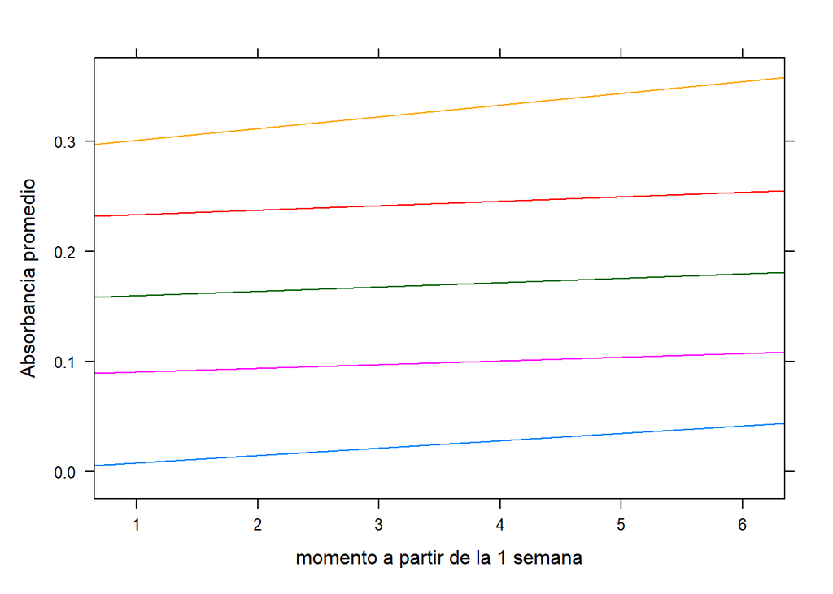

```r
obj = as.numeric(base$objeto)

for(i in 1:length(table(base$objeto))){
   mod=lm(absorbancia~momento,base[obj==i,])
   beta0[i]=mod$coef[1]
   beta1[i]=mod$coef[2]
}

# se crea el grafico
xyplot(absorbancia~momento,group=objeto,pch=18,
xlab="momento a partir de la 1 semana",
ylab="Absorbancia promedio",type="r",data = base)
```

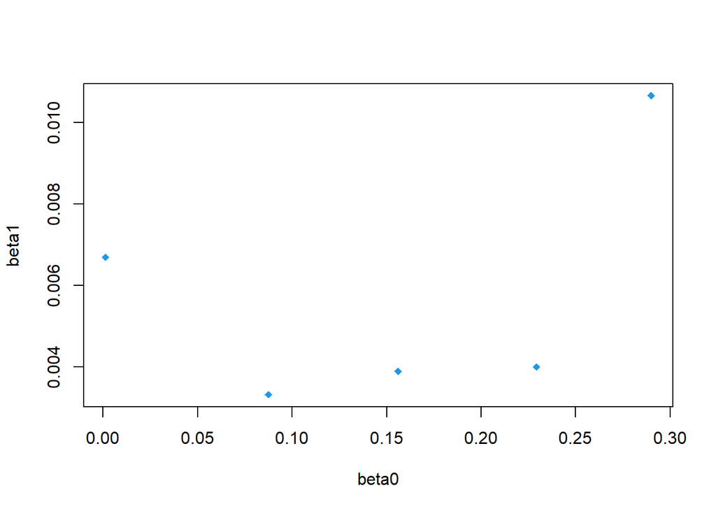

```r
plot(beta0,beta1,pch=18, col=4)
```

```r
cor(beta0,beta1)
```

```
## [1] 0.3947549
```

En general se observa que las pendientes no van decreciendo conforme aumenta el intercepto. La correlacion es 0.39 la cual es media. No parece haber una relación fuerte entre la absorbancia en el momento 1 y la pendiente de cada objeto.

# graficos para el nivel de concentración

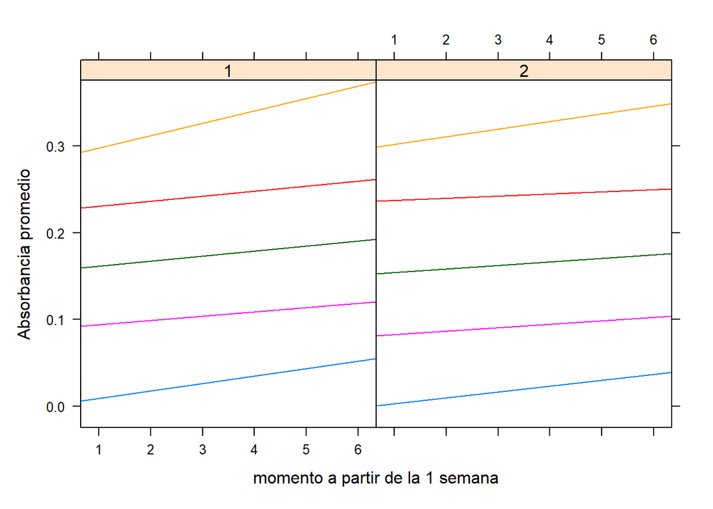

```r
xyplot(absorbancia~momento|niv_concentracion,group=objeto,pch=18,
xlab="momento a partir de la 1 semana",
ylab="Absorbancia promedio",type=c("r"), data = base)
```

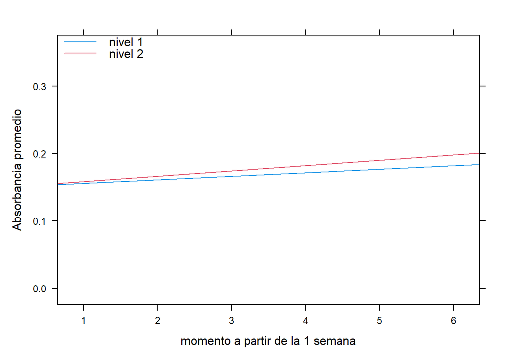

```r
xyplot(absorbancia~momento,group=niv_concentracion,col=c(2,4),
xlab="momento a partir de la 1 semana",
ylab="Absorbancia promedio",type="r",
key=list(corner=c(0,1),lines=list(col=c(4,2),lty=1),
text=list(c("nivel 1","nivel 2"))), data = base)
```

# Verificación de hipotesis

# 1. correlacion

$H0: \rho=0 \\ H1: \rho \neq 0$

Primero se descarta que haya correlacion entre las pendientes y los interceptos

```r
library(lme4)
options(contrasts=c("contr.sum","contr.poly")) # esto es para hacerlo suma nula
mod1=lmer(absorbancia~momento*niv_concentracion+(1+momento|objeto),REML=F, data = base)
```

```
## boundary (singular) fit: see help('isSingular')
```

```r
mod2=lmer(absorbancia~momento*niv_concentracion+(1|objeto)+(0+momento|objeto),REML=F, data = base)
anova(mod1,mod2)
```

```
## Data: base
## Models:
## mod2: absorbancia ~ momento * niv_concentracion + (1 | objeto) + (0 + momento | objeto)
## mod1: absorbancia ~ momento * niv_concentracion + (1 + momento | objeto)
##      npar     AIC     BIC logLik deviance  Chisq Df Pr(>Chisq)
## mod2    7 -137.91 -128.10 75.953  -151.91
## mod1    8 -137.01 -125.81 76.507  -153.01 1.1075  1     0.2926
```

La probabilidad asociada al comparar los dos modelos es alta (mayor a 0.05) por lo que no se rechaza la hipotesis que no hay correlacion entre pendientes e interceptos (osea que son independientes). El modelo 2 es el elegido para continuar el analisis.

# 2.Pendientes

$H0: \sigma^2_1 = 0 \\ H1: \sigma^1_1 \neq 0$

Luego se descarta que que las pendientes sean diferentes entre objetos de un mismo nivel de concentracion. En este paso se crea un modelo que no contenga las pendientes aleatorias (mod 3) y se compara con el modelo que si tenia estas pendientes (mod2).

```r
mod3 = lmer(absorbancia~momento*niv_concentracion+(1|objeto), REML = F, data = base)
anova(mod3,mod2)
```

```
## Data: base
## Models:
## mod3: absorbancia ~ momento * niv_concentracion + (1 | objeto)
## mod2: absorbancia ~ momento * niv_concentracion + (1 | objeto) + (0 + momento | objeto)
##      npar     AIC     BIC logLik deviance Chisq Df Pr(>Chisq)
## mod3    6 -139.89 -131.48 75.943  -151.89
## mod2    7 -137.91 -128.10 75.953  -151.91 0.021  1     0.8847
```

Con una probabilidad alta de 0.88 se elcoge el modelo mas simple, es decir que se descarta que hayan pendientes especificas para cada objeto.

# 3. Interaccion

$H0: \gamma_j = 0 \quad \forall j \\ H1: \gamma_j \neq 0$

```r
mod4 = lmer(absorbancia~momento+niv_concentracion+(1|objeto), REML = F, data = base)
anova(mod4,mod3)
```

```
## Data: base
## Models:
## mod4: absorbancia ~ momento + niv_concentracion + (1 | objeto)
## mod3: absorbancia ~ momento * niv_concentracion + (1 | objeto)
##      npar     AIC     BIC logLik deviance  Chisq Df Pr(>Chisq)
## mod4    5 -140.84 -133.83 75.417  -150.84
## mod3    6 -139.89 -131.48 75.943  -151.89 1.0511  1     0.3053
```

Al obtener una probabilidad alta (0.30), no se rechaza la hipotesis de no interaccion. Es decir que la interaccion no es significativa, es decir que el incremento de la absorbancia en los distintos momentos es la misma para ambos niveles de concentracion. En este caso me quedo con el modelo 4.

```r
summary(mod4)$coef
```

```
##                     Estimate  Std. Error  t value
## (Intercept)        0.1499292 0.047634488 3.147492
## momento            0.0065250 0.001306002 4.996163
## niv_concentracion1 0.0047625 0.002230423 2.135245
```